# README

**REQUIRED** — An OAuth Client is required to use this module.

Follow the steps below to learn how to create an OAuth Client and enter it into the Fitbit module.

## Steps to finish setup

- Log into Fitbit Developer Center
- Create an application
- Enter your OAuth information into Infinity Dashboard
- Authorize the module

## What is an OAuth Client and why do I need it?

> OAuth is an open standard for access delegation, commonly used as a way for Internet users to grant websites or applications access to their information on other websites but without giving them the passwords.

The Fitbit API request OAuth authorization in order to access the data stored on Fitbit.

## Logging into Fitbit Developer Center

- Click the following link to open the Fitbit Developer – [Register an application](https://dev.fitbit.com/apps/new) page
- You may be asked to sign in
  - Follow the on screen steps to sign in with your Fitbit account.
- Continue to the next step to create an application.

## Creating an application

After signing in you will be presented with the following screen:

[figure not shown]

- Fill out the form so it looks like the following:

[figure not shown]

- Click the `Register` button to continue
- You will be presented with a page that contains your OAuth Client ID and Secret

[figure not shown]

- Copy the value under the **OAuth 2.0 Client ID** section
- Enter it into the Infinity Dashboard under the **Client ID** option
- Copy the value under the **Client Secret** section
- Enter it into the Infinity Dashboard under the **Client Secret** option
- Continue to the next step

## Authorize the module

**Note** — The authorization process will time out after a few minutes. If this happens you will need to restart the process by running the module again.

- Once you enter the above information a notification will appear that says the following:

[figure not shown]

- Click continue to open the authorization website in your browser

[figure not shown]

- Click the **Allow All** checkbox
- Click the `Allow` button
- You should be brought to a page that looks like the following:

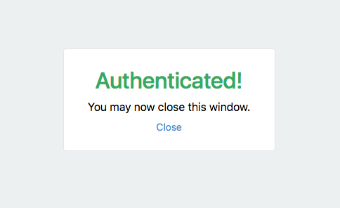

**Success** — You’re All Set!

## I see an authorization failed message

- Repeat the steps above and make sure all the fields are entered as specified, especially the callback URL.
- If this still doesn’t work, double check to make sure the Client ID and Secret values are being entered correctly.